# Modelando la probabilidad de incumplimiento

Alondra Matos, María López

2023-12-03

### Descripción de la base de datos

```
 home_ownership      addr_state        verification_status   purpose
 Length:466285      Length:466285      Length:466285       Length:466285
 Class :character   Class :character   Class :character    Class :character
 Mode  :character   Mode  :character   Mode  :character    Mode  :character




 initial_list_status    grade               term            emp_length
 Length:466285       Length:466285      Length:466285      Length:466285
 Class :character    Class :character   Class :character   Class :character
 Mode  :character    Mode  :character   Mode  :character   Mode  :character




 acc_now_delinq     inq_last_6mths      annual_inc         int_rate
 Min.   :0.000000   Min.   : 0.0000   Min.   :   1896   Min.   : 5.42
 1st Qu.:0.000000   1st Qu.: 0.0000   1st Qu.:  45000   1st Qu.:10.99
 Median :0.000000   Median : 0.0000   Median :  63000   Median :13.66
 Mean   :0.004002   Mean   : 0.8047   Mean   :  73277   Mean   :13.83
 3rd Qu.:0.000000   3rd Qu.: 1.0000   3rd Qu.:  88960   3rd Qu.:16.49
 Max.   :5.000000   Max.   :33.0000   Max.   :7500000   Max.   :26.06
 NA's   :29         NA's   :29        NA's   :4
 mths_since_last_delinq mths_since_last_record   member_id
 Min.   :  0.0          Min.   :  0.0          Min.   :   70473
 1st Qu.: 16.0          1st Qu.: 53.0          1st Qu.: 4379705
 Median : 31.0          Median : 76.0          Median :11941075
 Mean   : 34.1          Mean   : 74.3          Mean   :14597661
 3rd Qu.: 49.0          3rd Qu.:102.0          3rd Qu.:23001541
 Max.   :188.0          Max.   :129.0          Max.   :40860827
 NA's   :250351         NA's   :403647
 loan_status
 Length:466285
 Class :character
 Mode  :character
```

```
  home_ownership addr_state verification_status        purpose
1           RENT         AZ            Verified    credit_card
2           RENT         GA     Source Verified            car
3           RENT         IL        Not Verified small_business
4           RENT         CA     Source Verified          other
5           RENT         OR     Source Verified          other
  initial_list_status grade       term emp_length acc_now_delinq inq_last_6mths
1                   f     B  36 months  10+ years              0              1
2                   f     C  60 months   < 1 year              0              5
3                   f     C  36 months  10+ years              0              2
4                   f     C  36 months  10+ years              0              1
5                   f     B  60 months     1 year              0              0
  annual_inc int_rate mths_since_last_delinq mths_since_last_record member_id
1      24000    10.65                     NA                     NA   1296599
2      30000    15.27                     NA                     NA   1314167
3      12252    15.96                     NA                     NA   1313524
4      49200    13.49                     35                     NA   1277178
5      80000    12.69                     38                     NA   1311748
  loan_status
1  Fully Paid
2 Charged Off
3  Fully Paid
4  Fully Paid
5     Current
```

#### Tratamiento de datos faltantes

*Visualización de datos faltantes*

Se comprueba la presencia de cadenas de texto vacías en alguna de las variables.

```r
# Contar cuántos valores son cadenas de texto vacías en cada columna
conteo_vacios <- apply(datos=="", 2, sum)

#Imprimir los resultados para cada columnas
for ( i in seq_along(conteo_vacios)){
  if(names(conteo_vacios)[i] %in% factor_var){
  cat("Variable ", names(conteo_vacios)[i],":", conteo_vacios[i], "\n")
  }
}
```

```
Variable  home_ownership : 0
Variable  addr_state : 0
Variable  verification_status : 0
Variable  purpose : 0
Variable  initial_list_status : 0
Variable  grade : 0
Variable  term : 0
Variable  emp_length : 21008
Variable  acc_now_delinq : NA
Variable  inq_last_6mths : NA
```

Se observa que *emp_length* es la única variable con cadenas vacías, las cuales se reemplazarán por “< 1 year”-

```r
datos$emp_length[which(datos$emp_length=="")]="< 1 year"
```

La siguiente gráfica permite visualizar la distribución de valores perdidos en tu conjunto de datos.

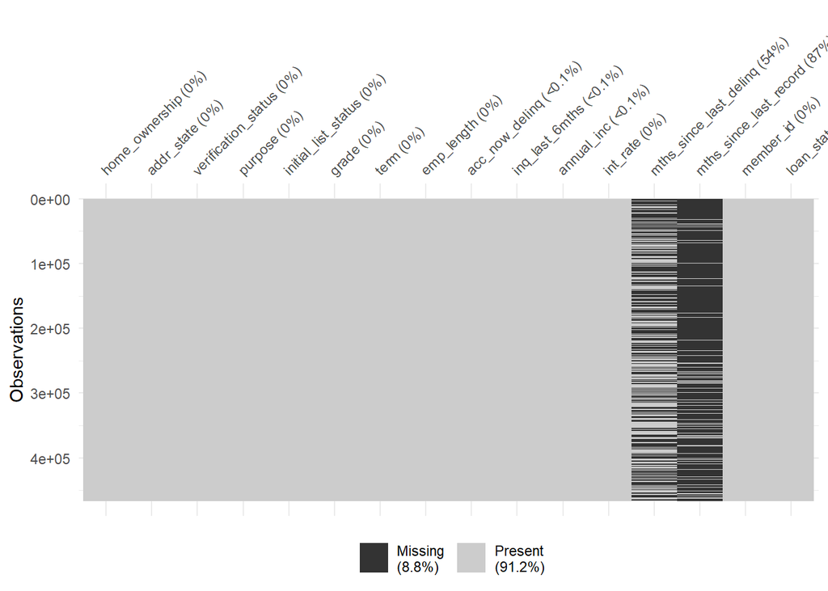

```r
datos$inq_last_6mths[which(is.na(datos$inq_last_6mths))]=0
datos$acc_now_delinq[which(is.na(datos$acc_now_delinq))]=0

# Eliminar las filas con NA en variable income
datos <- datos[complete.cases(datos$annual_inc), ]
```

```r
library(dplyr)

datos$emp_length[datos$emp_length == "10+ years"] <- "9+ years"
#datos$emp_length<- factor(datos$emp_length, levels = c("< 1 year",  "1 year","2 years" ,"3 years",   "4 years",   "5 years",   "6 years" ,"7 years",  "8 years", "9 years","10+ years"))

# Convertir las variables discretas en factores
datos <- datos %>%
  mutate_at(vars(factor_var), factor)
```

#### Creación de variables

*Variable de respuesta*

El estado de préstamo de cada cliente puede clasificarse en alguna de las siguientes categorías:

```
[1] "Fully Paid"
[2] "Charged Off"
[3] "Current"
[4] "Default"
[5] "Late (31-120 days)"
[6] "In Grace Period"
[7] "Late (16-30 days)"
[8] "Does not meet the credit policy. Status:Fully Paid"
[9] "Does not meet the credit policy. Status:Charged Off"
```

Los clientes considerados malos son aquellos cuyo estatus de préstamo se encuentra entre:

- Charged Off
- Default
- Does not meet the credit policy. Status:Charged Off
- Late (31-120 days)

Se crea la variable de respuesta que clasifica a los clientes como buenos (1) o malos (0) en función de su historial crediticio. La proporción de buenos(1) y malos(0) es:

```r
nom_malos <- c("Charged Off","Default",
            "Does not meet the credit policy. Status:Charged Off",
            "Late (31-120 days)")

# Se agrega la variable de respuesta
datos$y <-ifelse(datos$loan_status%in%nom_malos,"0","1")

# Proporción de buenos(1) y malos(0)
freq_y <- table(datos[,"y"])
prop.table(freq_y)
```

```
        0         1
0.1093075 0.8906925
```

#### Creación de los datos de entrenamiento y prueba

```
[1] 0
```

### Tratamiento de variables discretas

#### Coarse Classing

El Coarse Classing consiste en agrupar categorías adyacentes con puntuaciones WOE similares, pues al tener proporciones similares de eventos y no eventos, ambas categorías exhiben un comportamiento similar. Para llevar a cabo esta técnica, es necesario cumplir con los siguientes criterios:

- Cada categoría (intervalo) debe abarcar al menos el 5% de las observaciones.
- Cada categoría (intervalo) debe tener una presencia distinta de cero tanto para eventos (por ejemplo, “clientes buenos”) como para no eventos (por ejemplo, “clientes malos”).
- Las puntuaciones WOE deben ser diferentes para cada categoría, y se deben agrupar aquellas que sean similares.
- Las puntuaciones WOE deben seguir una tendencia monótona, es decir, aumentar o disminuir de manera consistente a través de los grupos.
- Los valores faltantes se agrupan de manera independiente.

```
Variable: home_ownership
         Categoria         WOE Total_buenos Total_malos  Total Total_porcentaje
ANY            ANY -1.00223565            0           1      1     2.680793e-06
NONE          NONE -0.87707251            7          25     32     8.578537e-05
OTHER        OTHER -0.64859561           27         117    144     3.860341e-04
RENT          RENT -0.16113521        18960      131903 150863     4.044324e-01
OWN            OWN  0.01131961         3601       29770  33371     8.946073e-02
MORTGAGE  MORTGAGE  0.14386168        18070      170543 188613     5.056323e-01
```

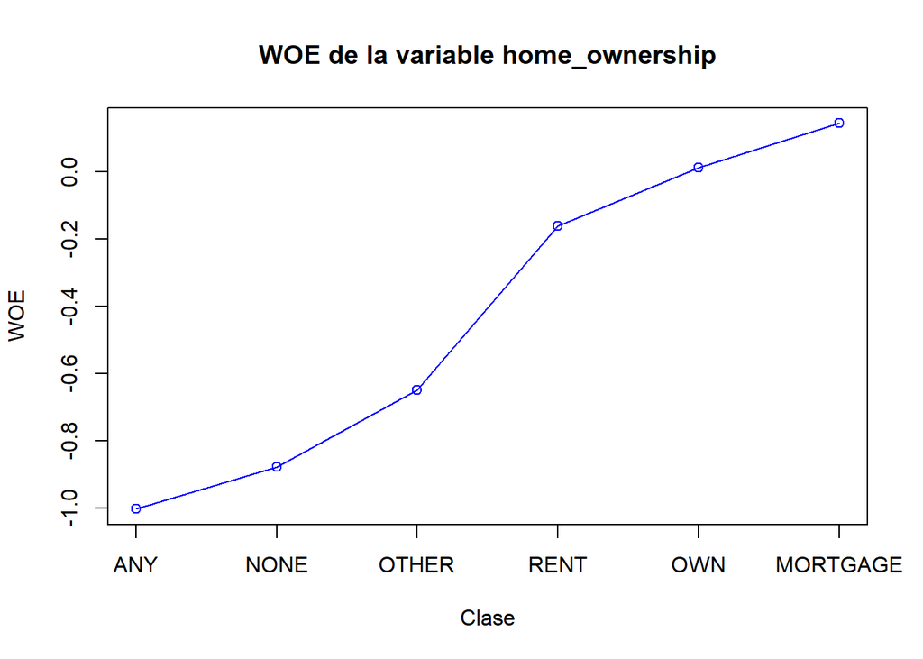

```
Variable: addr_state
   Categoria          WOE Total_buenos Total_malos Total Total_porcentaje
NE        NE -2.100847938            6           6    12     3.216951e-05
IA        IA -1.213544743            3           8    11     2.948872e-05
ID        ID -0.366246883            1           8     9     2.412713e-05
NV        NV -0.224335959          692        4522  5214     1.397765e-02
HI        HI -0.150937784          249        1753  2002     5.366947e-03
FL        FL -0.148335165         3148       22185 25333     6.791252e-02
AL        AL -0.117353509          559        4066  4625     1.239867e-02
LA        LA -0.111722001          530        3877  4407     1.181425e-02
NY        NY -0.083823914         3783       28436 32219     8.637246e-02
MD        MD -0.069972164         1016        7746  8762     2.348911e-02
NC        NC -0.067931476         1175        8976 10151     2.721273e-02
MO        MO -0.064724089          688        5274  5962     1.598289e-02
NM        NM -0.064698545          237        1819  2056     5.511710e-03
OK        OK -0.047483716          371        2895  3266     8.755469e-03
NJ        NJ -0.045963725         1651       12891 14542     3.898409e-02
VA        VA -0.043080669         1285       10063 11348     3.042164e-02
CA        CA -0.040642343         6485       50895 57380     1.538239e-01
TN        TN -0.036784994          536        4226  4762     1.276593e-02
MI        MI -0.016867948         1030        8281  9311     2.496086e-02
AZ        AZ -0.015126422          942        7587  8529     2.286448e-02
RI        RI -0.009722780          175        1420  1595     4.275864e-03
OH        OH -0.004720364         1333       10847 12180     3.265205e-02
MN        MN -0.003041287          711        5797  6508     1.744660e-02
PA        PA  0.010918332         1413       11679 13092     3.509694e-02
KY        KY  0.012857173          385        3191  3576     9.586515e-03
MA        MA  0.025754763          943        7912  8855     2.373842e-02
DE        DE  0.031252244          107         906  1013     2.715643e-03
UT        UT  0.033410475          289        2446  2735     7.331968e-03
IN        IN  0.034299792          557        4715  5272     1.413314e-02
AR        AR  0.037708791          292        2482  2774     7.436519e-03
GA        GA  0.044547314         1249       10677 11926     3.197113e-02
WA        WA  0.058836264          865        7502  8367     2.243019e-02
ME        ME  0.096376639            0           4     4     1.072317e-05
WI        WI  0.096611767          472        4253  4725     1.266675e-02
SD        SD  0.099277294           76         690   766     2.053487e-03
OR        OR  0.109663548          473        4318  4791     1.284368e-02
TX        TX  0.143490815         2791       26335 29126     7.808077e-02
CT        CT  0.145238624          552        5221  5773     1.547622e-02
SC        SC  0.173367321          416        4048  4464     1.196706e-02
IL        IL  0.177392583         1382       13492 14874     3.987411e-02
CO        CO  0.190927002          711        7038  7749     2.077346e-02
MT        MT  0.196249488          100         999  1099     2.946191e-03
AK        AK  0.203411729           89         896   985     2.640581e-03
KS        KS  0.205820460          305        3067  3372     9.039633e-03
MS        MS  0.263840077           83         888   971     2.603050e-03
VT        VT  0.267037581           61         656   717     1.922128e-03
NH        NH  0.299460609          150        1659  1809     4.849554e-03
WV        WV  0.350662480          153        1781  1934     5.184653e-03
WY        WY  0.388187293           70         849   919     2.463648e-03
DC        DC  0.557418227           75        1077  1152     3.088273e-03
```

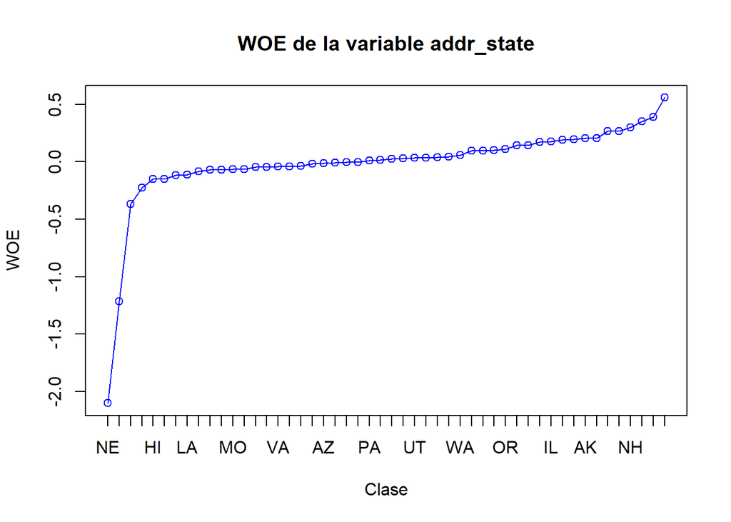

```
Variable: verification_status
                      Categoria         WOE Total_buenos Total_malos  Total
Verified               Verified -0.17800266        17173      117473 134646
Source Verified Source Verified  0.05897928        12389      107412 119801
Not Verified       Not Verified  0.16914530        11103      107474 118577
                Total_porcentaje
Verified               0.3609580
Source Verified        0.3211616
Not Verified           0.3178804
```

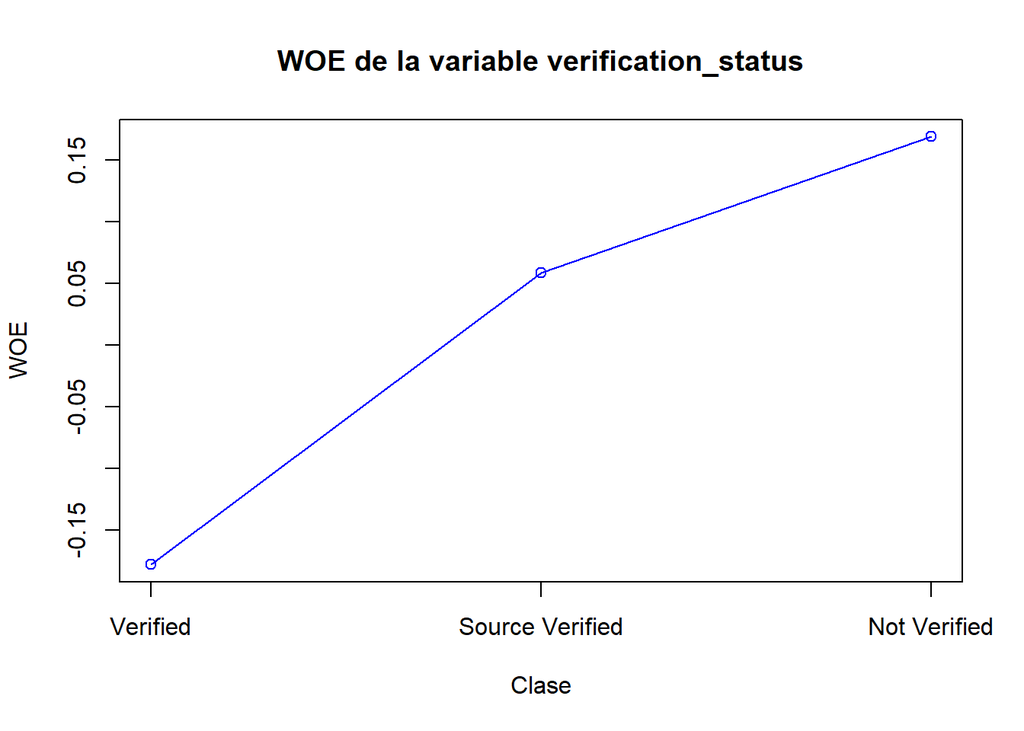

```
Variable: purpose
                            Categoria         WOE Total_buenos Total_malos
small_business         small_business -0.81592639         1230        4447
educational               educational -0.77679589           72         272
moving                         moving -0.39548826          371        2044
renewable_energy     renewable_energy -0.33198229           40         237
other                           other -0.27238280         2614       16273
house                           house -0.25608940          246        1559
medical                       medical -0.24344016          492        3155
vacation                     vacation -0.07662919          231        1752
wedding                       wedding -0.07006545          214        1634
debt_consolidation debt_consolidation -0.03669435        24696      194574
home_improvement     home_improvement  0.10896235         2105       19189
major_purchase         major_purchase  0.13539758          759        7107
credit_card               credit_card  0.25395833         7225       76128
car                               car  0.27546912          370        3988
                    Total Total_porcentaje
small_business       5677     0.0152188599
educational           344     0.0009221927
moving               2415     0.0064741143
renewable_energy      277     0.0007425796
other               18887     0.0506321309
house                1805     0.0048388307
medical              3647     0.0097768508
vacation             1983     0.0053160118
wedding              1848     0.0049541048
debt_consolidation 219270     0.5878174059
home_improvement    21294     0.0570847988
major_purchase       7866     0.0210871150
credit_card         83353     0.2234521103
car                  4358     0.0116828944
```

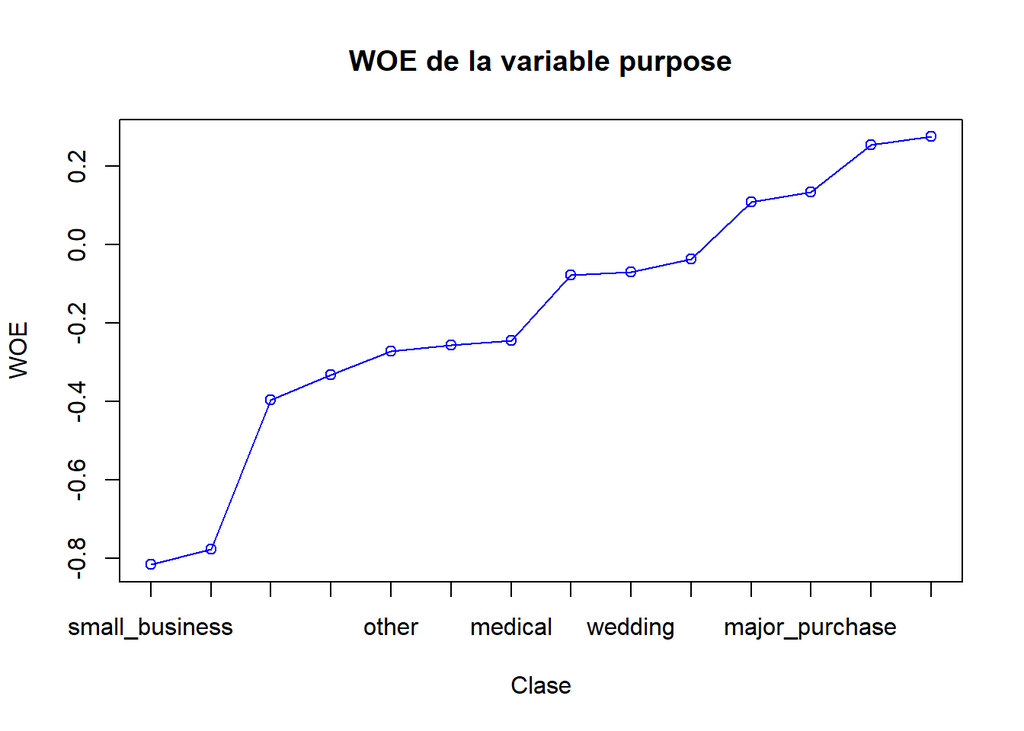

```
Variable: initial_list_status
  Categoria        WOE Total_buenos Total_malos  Total Total_porcentaje
f         f -0.1082686        29106      213479 242585        0.6503201
w         w  0.2297632        11559      118880 130439        0.3496799
```

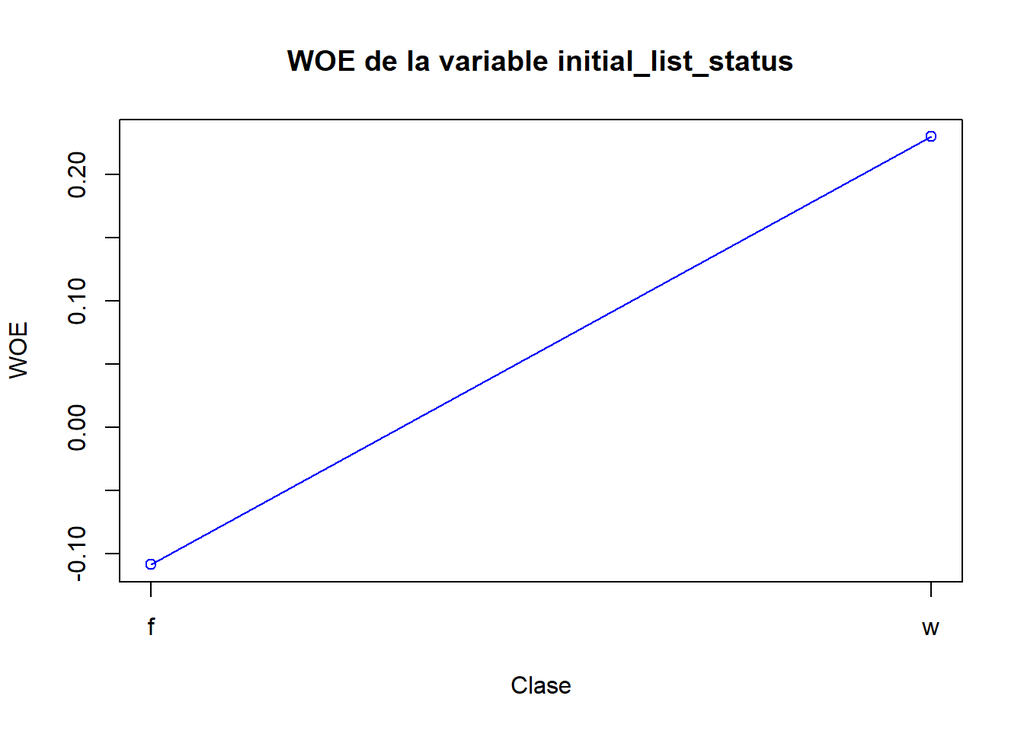

```
Variable: grade
  Categoria         WOE Total_buenos Total_malos  Total Total_porcentaje
A         A  1.10931346         2323       57583  59906      0.160595565
B         B  0.36012588         8624      101046 109670      0.294002531
C         C -0.05898458        11518       88749 100267      0.268795037
D         D -0.39027774         9411       52065  61476      0.164804409
E         E -0.67031301         5507       23026  28533      0.076491057
F         F -0.95187912         2536        8002  10538      0.028250193
G         G -1.17270541          746        1888   2634      0.007061208
```

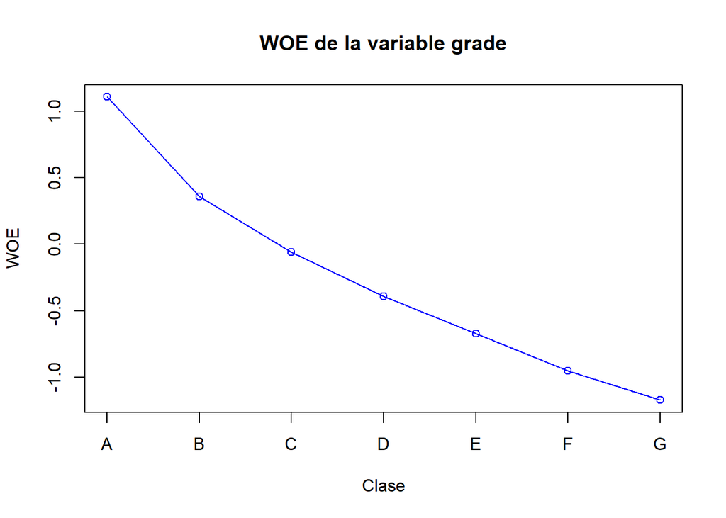

```
Variable: term
            Categoria        WOE Total_buenos Total_malos  Total
 36 months  36 months  0.1296129        26256      244294 270550
 60 months  60 months -0.2906548        14409       88065 102474
           Total_porcentaje
 36 months        0.7252885
 60 months        0.2747115
```

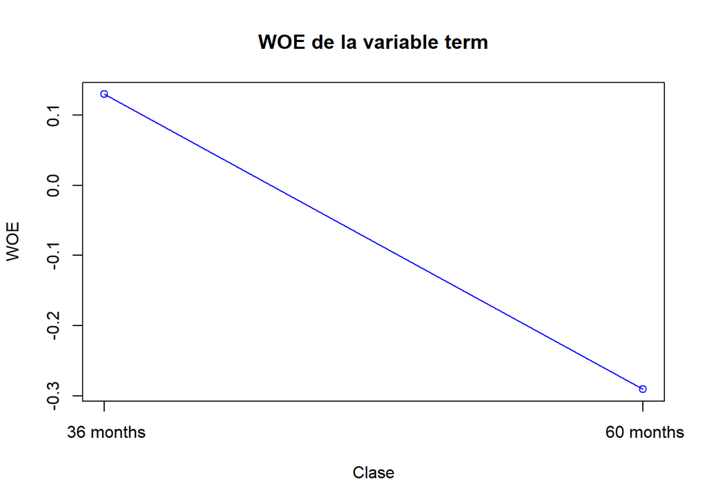

```
Variable: emp_length
         Categoria           WOE Total_buenos Total_malos  Total
< 1 year  < 1 year -0.1405629253         5663       40218  45881
1 year      1 year -0.0272885582         2653       21103  23756
2 years    2 years -0.0127390457         3654       29490  33144
3 years    3 years -0.0002847923         3188       26052  29240
4 years    4 years -0.0001249695         2449       20017  22466
5 years    5 years -0.0669367576         2843       21735  24578
6 years    6 years -0.0699736016         2424       18476  20900
7 years    7 years -0.0170144568         2314       18597  20911
8 years    8 years  0.0022838037         1947       15953  17900
9 years    9 years -0.0312268302         1592       12615  14207
9+ years  9+ years  0.1024726912        11938      108103 120041
         Total_porcentaje
< 1 year       0.12299745
1 year         0.06368491
2 years        0.08885219
3 years        0.07838638
4 years        0.06022669
5 years        0.06588852
6 years        0.05602857
7 years        0.05605806
8 years        0.04798619
9 years        0.03808602
9+ years       0.32180503
```

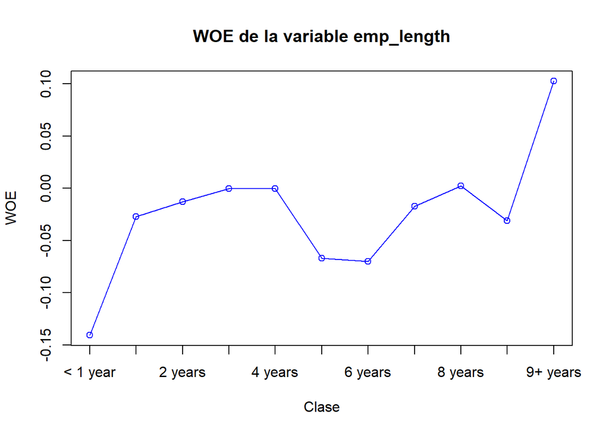

```
Variable: acc_now_delinq
  Categoria           WOE Total_buenos Total_malos  Total Total_porcentaje
0         0 -8.393966e-05        40516      331117 371633     9.962710e-01
1         1  2.199292e-02          139        1165   1304     3.495754e-03
2         2 -5.886396e-02            8          65     73     1.956979e-04
3         3 -8.770725e-01            2           8     10     2.680793e-05
4         4 -1.549378e-01            0           3      3     8.042378e-06
5         5 -1.002236e+00            0           1      1     2.680793e-06
```

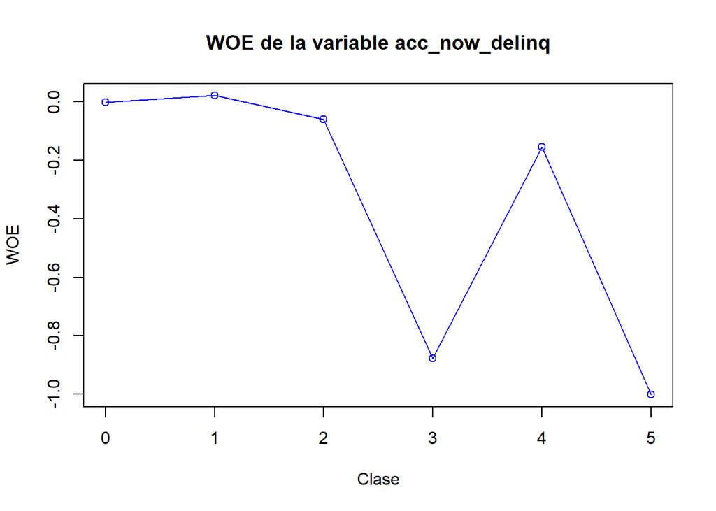

```
Variable: inq_last_6mths
   Categoria         WOE Total_buenos Total_malos  Total Total_porcentaje
0          0  0.20027131        17579      175537 193116     5.177040e-01
1          1 -0.05818974        11963       92251 104214     2.793761e-01
2          2 -0.25316014         6300       39977  46277     1.240590e-01
3          3 -0.43845379         3199       16867  20066     5.379279e-02
4          4 -0.38407545          875        4873   5748     1.540920e-02
5          5 -0.53045482          386        1858   2244     6.015699e-03
6          6 -0.88685836          223         752    975     2.613773e-03
7          7 -1.52493085           56         100    156     4.182037e-04
8          8 -1.57994666           39          66    105     2.814832e-04
9          9 -1.49178388           15          28     43     1.152741e-04
10        10 -0.82788226            3          12     15     4.021189e-05
11        11 -1.10231911            3           9     12     3.216951e-05
12        12 -1.72135832            6           9     15     4.021189e-05
13        13 -1.76437570            2           3      5     1.340396e-05
14        14 -3.19946023            4           1      5     1.340396e-05
15        15 -2.30151863            5           4      9     2.412713e-05
16        16 -0.15493779            0           3      3     8.042378e-06
17        17 -2.10084794            1           1      2     5.361585e-06
18        18 -2.10084794            2           2      4     1.072317e-05
19        19 -0.49141003            0           2      2     5.361585e-06
20        20 -3.19946023            1           0      1     2.680793e-06
24        24 -1.00223565            0           1      1     2.680793e-06
25        25 -3.19946023            1           0      1     2.680793e-06
27        27 -1.00223565            0           1      1     2.680793e-06
28        28 -1.00223565            0           1      1     2.680793e-06
31        31 -1.00223565            0           1      1     2.680793e-06
32        32 -3.19946023            1           0      1     2.680793e-06
33        33 -3.19946023            1           0      1     2.680793e-06
```

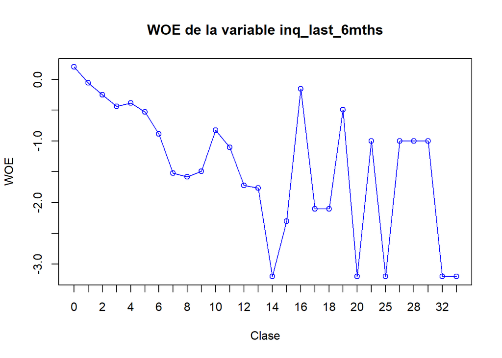

```r
calculate_woe <- function(data, target_variable, name_vars ) {

  # Inicializar una lista para almacenar los resultados
  woe_list <- list()

  # Calcular WOE para cada variable categórica
  for (var in name_vars) {

    # Crear una tabla de contingencia
    table_var <- table(data[[var]], data[[target_variable]])

    # Calcular porcentajes de buenos y malos
    # Si un contenedor en particular no contiene ningún evento o ningún evento, se puede usar
    # la siguiente fórmula para ignorar el WOE faltante. Se suman 0,5 al número
    # de eventos y no eventos en un grupo.

    bad <- table_var[, 2]
    good <- table_var[, 1]
    good_percentage <- (table_var[, 2] + 0.5 )/ sum(table_var[, 2])
    bad_percentage <- (table_var[, 1] + 0.5)/  sum(table_var[, 1])

    # Calcular WOE  ajustado
    woe <- log(good_percentage / bad_percentage)



    # Almacenar resultados en la lista
    woe_list[[var]]<- data.frame(
      Categoria = names(table_var[, 1]),
      WOE = woe,
      Total_buenos = good,
      Total_malos = bad,
      Total = good + bad,
      Total_porcentaje = (good + bad)/nrow(data)

     )

    if(var %in% c(nominal_var)){
     # Ordenar
      woe_list[[var]] <- woe_list[[var]][order(woe_list[[var]]$WOE), ]
    }
    else{
      woe_list[[var]] <- woe_list[[var]]
     }

  }

  # Devolver la lista de resultados
  return(woe_list)
}

# Funcion de la gráfica del WOE
plot_woe <- function(df,var_name ){
  plot(1:nrow(df), df$WOE, type = "o", col = "blue", xaxt = "n",
            xlab = "Clase",ylab ="WOE", main = paste("WOE de la variable",var_name))
  axis(1, labels = df$Categoria, at = 1:nrow(df))
}

# Obtener las variables categóricas
categorical_vars <- names(train)[sapply(train, function(x) is.factor(x) )]
categorical_vars <- categorical_vars[!categorical_vars %in% c("y","loan_status",
                                                               "issue_d", "earliest_cr_line")]
woe_results <- calculate_woe(train, "y", categorical_vars)

# Imprimir los resultados
for (i in seq_along(woe_results)) {
  cat("Variable:", names(woe_results)[i], "\n")
  print(woe_results[[i]])
  plot_woe(woe_results[[i]], var_name = names(woe_results)[i])
  cat("\n")
}
```

```r
are_similares <- function(df1, df2, threshold = 0.05) {
  # Verificar si dos filas son similares según puntuaciones WOE
  return(abs(tail(df1[,"WOE"], 1) - tail(df2[,"WOE"], 1)) <= threshold)
}

coarse_classing <- function(data, target, name_vars, threshold = 0.05, par_total_porcentaje = 0.05) {
  # Calcular las puntuaciones WOE
  woe_results <- calculate_woe(data, target, name_vars)

  # Inicializar lista de grupos
  grupos <- list()

  # Iterar sobre los resultados de WOE
  for (j in seq_along(woe_results)) {
    grupos[[j]] <- list()
    sorted_data <- woe_results[[j]]

    # Omitir si solo hay 2 categorías
    if (nrow(sorted_data) == 2) {
      grupos[[j]] <- sorted_data
      next
    }

    # Inicializar grupos para esta variable
    actual_grupo <- sorted_data[1, , drop = FALSE]
    k <- 1 # contador de elementos dentro de la lista de la variable

    # Iterar sobre las filas y agrupar categorías adyacentes con puntuaciones WOE similares
    for (i in 2:nrow(sorted_data)) {
      if (are_similares(sorted_data[i, , drop = FALSE], actual_grupo )) {
        if (sorted_data[i,"Total_porcentaje"] < par_total_porcentaje) {
          actual_grupo <- rbind(actual_grupo, sorted_data[i, , drop = FALSE])
        } else {
          grupos[[j]][[k]] <- actual_grupo
          actual_grupo <- sorted_data[i, , drop = FALSE]
          k <- k + 1
        }
      } else {
        if ((tail(actual_grupo[,"Total"], 1)/nrow(data)) > 0.05) {
          grupos[[j]][[k]] <- actual_grupo
          actual_grupo <- sorted_data[i, , drop = FALSE]
          k <- k + 1
        } else {
          if (sorted_data[i,"Total_porcentaje"] < 0.05) {
            actual_grupo <- rbind(actual_grupo, sorted_data[i, , drop = FALSE])
          } else {
            grupos[[j]][[k]] <- actual_grupo
            actual_grupo <- sorted_data[i, , drop = FALSE]
            k <- k + 1
          }
        }
      }
    }

    # Agregar el último grupo
    grupos[[j]][[k]] <- actual_grupo

    # Crear el dataframe de binning para cada grupo
    binning_df <- data.frame()

    for (h in seq_along(grupos[[j]])) {
      df <- grupos[[j]][[h]]
      Total_buenos <- sum(df$Total_buenos)
      Total_malos <- sum(df$Total_malos)
      Total <- sum(df$Total)

      binning_df <- rbind(binning_df, data.frame(
        Categoria = paste(df$Categoria, collapse = "_"),
        WOE = log((Total_buenos/sum(sorted_data[,"Total_buenos"])) /
                  (Total_malos/sum(sorted_data[,"Total_malos"]))),
        Total_buenos = Total_buenos,
        Total_malos = Total_malos,
        Total = Total,
        Total_porcentaje = Total/nrow(data)
      ))
    }

    Total_porcentaje <- binning_df[1, "Total_porcentaje"]
    new_binning_df <- list()
    new_binning <- binning_df[1, ]
    i <- 2
    r <- 1

  repeat {
    while (Total_porcentaje < 0.05) {
      new_binning <- rbind(new_binning, binning_df[i, ])
      Total_porcentaje <- Total_porcentaje + binning_df[i, "Total_porcentaje"]
      i <- i + 1

    if (i > nrow(binning_df)) {
      break
      }
    }

    new_binning_df[[r]] <- new_binning
    r <- r + 1

    if (i <= nrow(binning_df)) {
      new_binning <- binning_df[i, ]
      Total_porcentaje <- new_binning[1, "Total_porcentaje"]
      i <- i + 1
    }

    if (i > nrow(binning_df)) {
      break
    }
  }

  # Add the last binning_df if needed
  if (nrow(new_binning) > 0) {
    if(sum(new_binning[, "Total_porcentaje"])<0.05){
      new_binning_df[[r-1]] <- rbind(new_binning_df[[r-1]], new_binning )
    }else{
      if(!identical(new_binning_df[[r-1]],  new_binning)){
    new_binning_df[[r]] <- new_binning
      }
    }
  }

    # Create the dataframe of binning for each group
    binning_df_result <- data.frame()

    for (h in seq_along(new_binning_df)) {
      df <- new_binning_df[[h]]
      Total_buenos <- sum(df$Total_buenos)
      Total_malos <- sum(df$Total_malos)
      Total <- sum(df$Total)

      binning_df_result <- rbind(binning_df_result,
                                 data.frame(Categoria = paste(df$Categoria, collapse = "_"),
                                            WOE = log((Total_buenos/sum(sorted_data[,"Total_buenos"])) /
                                                      (Total_malos/sum(sorted_data[,"Total_malos"]))),
                                            Total_buenos = Total_buenos,
                                            Total_malos = Total_malos,
                                            Total = Total,
                                            Total_porcentaje = Total/nrow(data)
                                 ))
    }

    grupos[[j]] <- binning_df_result
  }

  # Asignar nombres a la lista
  names(grupos) <- name_vars

  return(grupos)
}
```

```
Variable: home_ownership
```

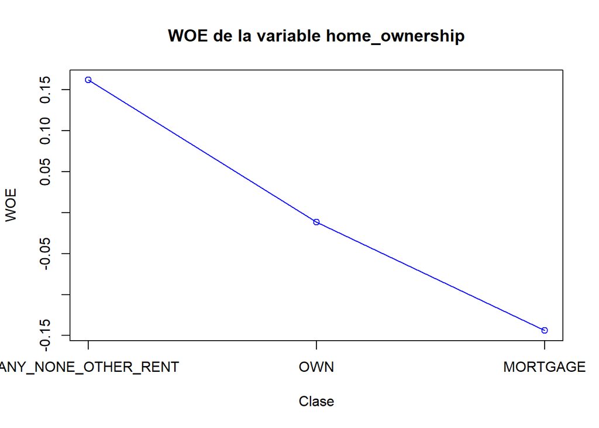

```
Variable: addr_state
```

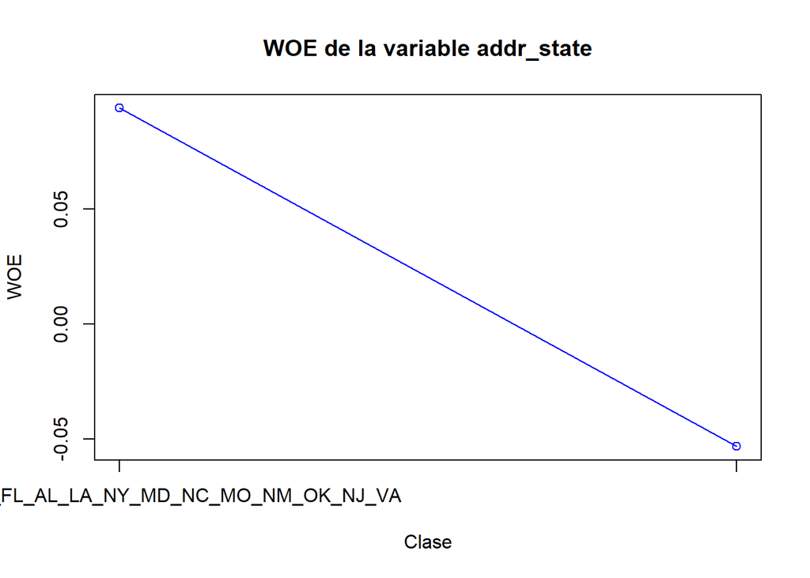

```
Variable: verification_status
```

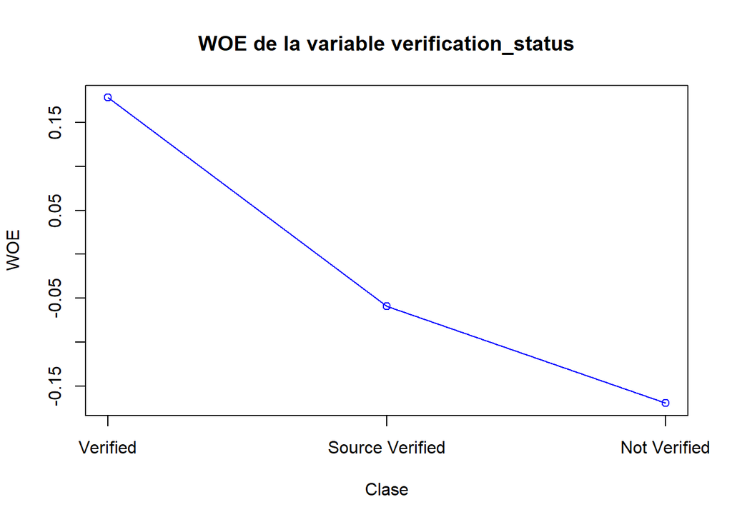

```
Variable: purpose
```

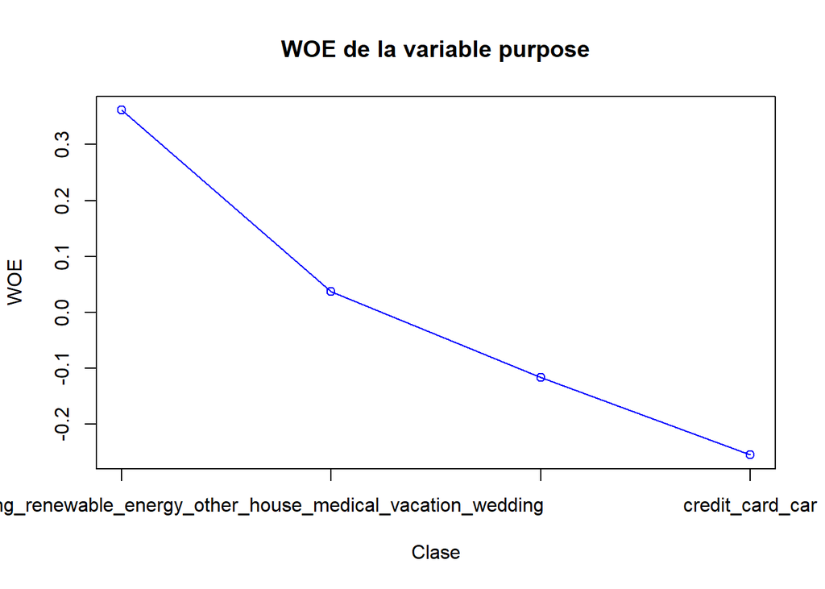

```
Variable: initial_list_status
```

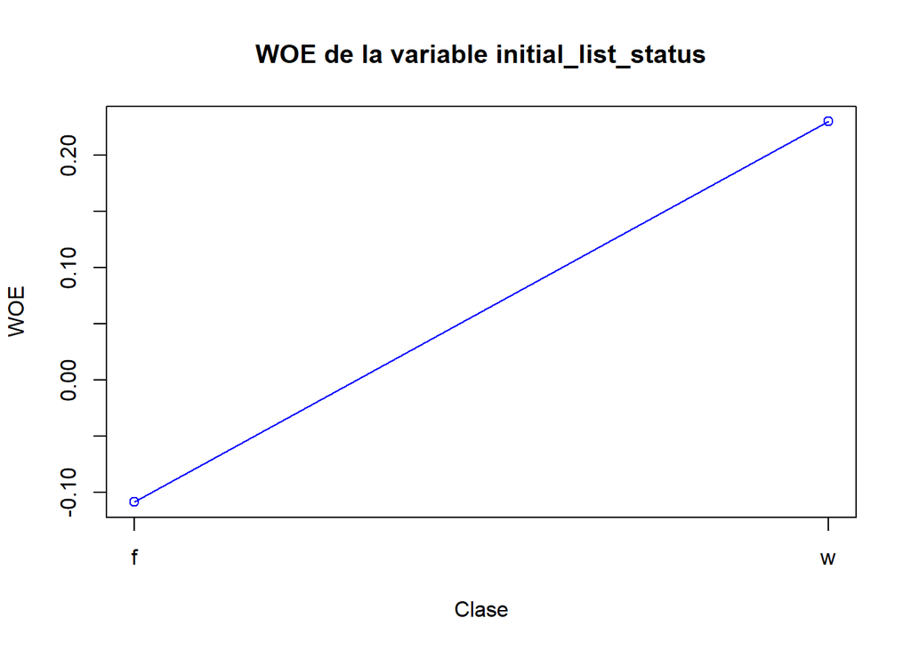

```
Variable: grade
```

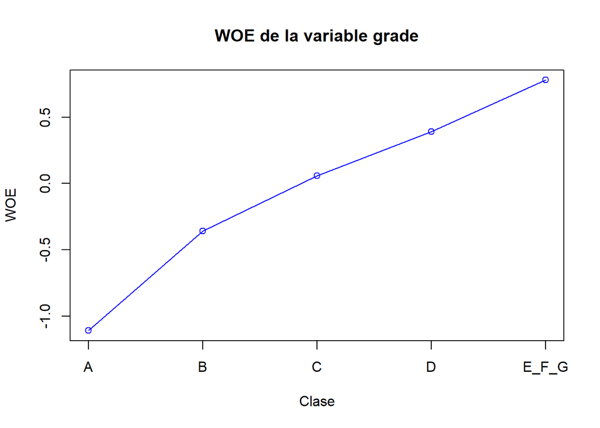

```
Variable: term
```

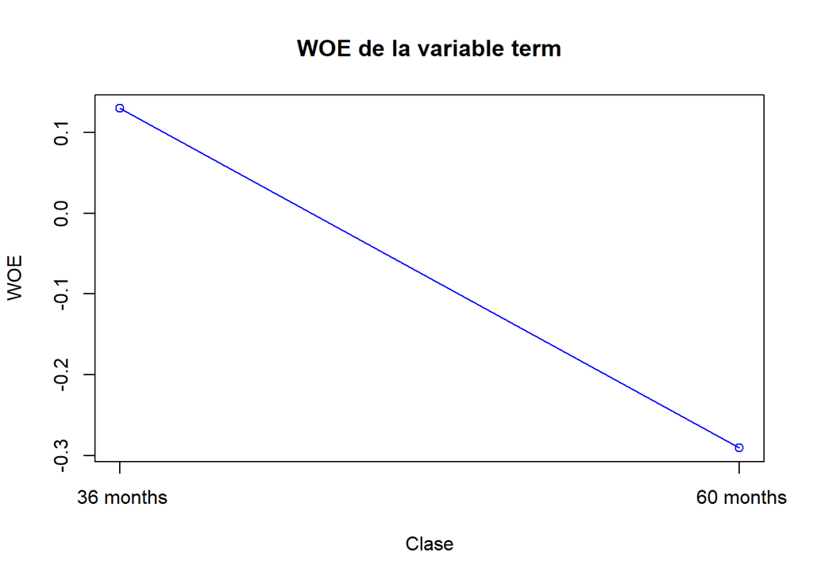

```
Variable: emp_length
```

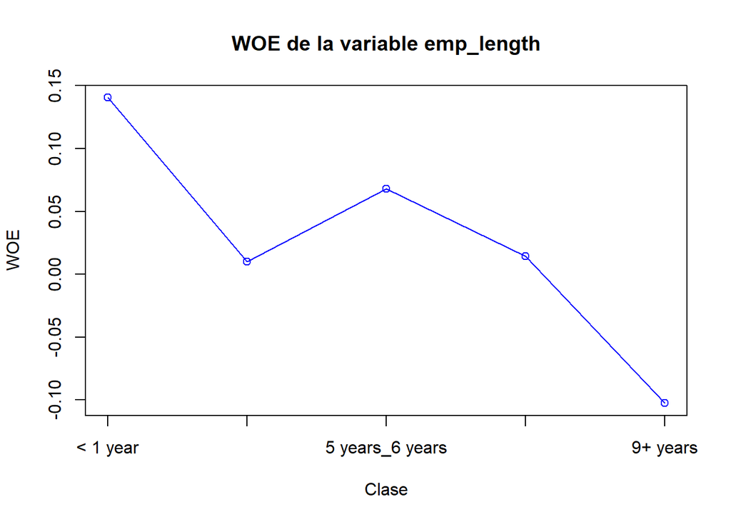

```
Variable: acc_now_delinq
```

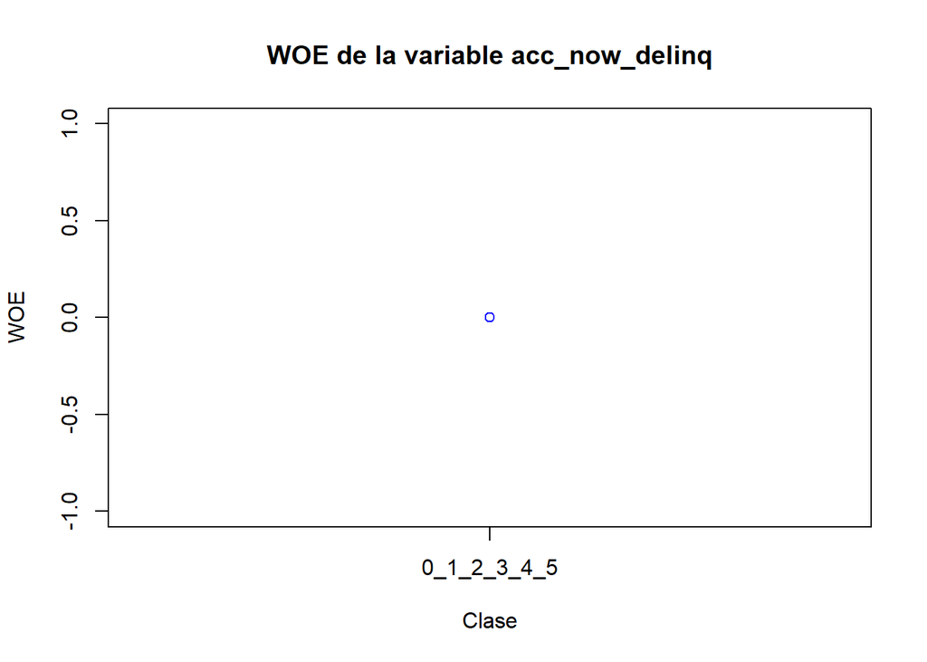

```
Variable: inq_last_6mths
```

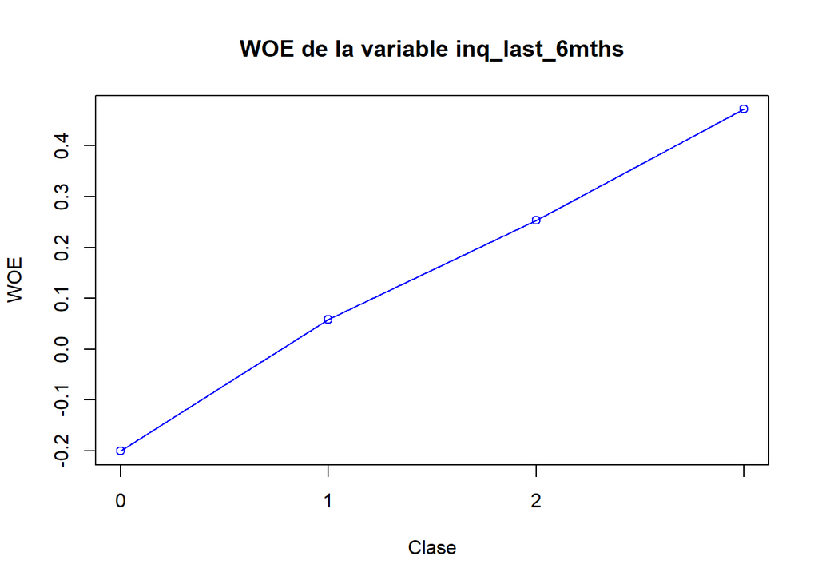

```r
coarse_classing_results <- coarse_classing(train, "y",threshold = 0.15,categorical_vars, 0.1)

categoric_label <- list()
# Imprimir los resultados
for (i in 1:length(coarse_classing_results)) {
  cat("Variable:", names(coarse_classing_results)[i], "\n")
  df_aux1 <- coarse_classing_results[[i]]
  categoric_label[[names(coarse_classing_results)[i]]] <- df_aux1$Categoria
  plot_woe(coarse_classing_results[[i]],
           var_name = names(coarse_classing_results)[i])
  cat("\n")
}
```

Nuevas categorías:

```r
coarse_classing_results
```

```
$home_ownership
            Categoria         WOE Total_buenos Total_malos  Total
1 ANY_NONE_OTHER_RENT  0.16182073        18994      132046 151040
2                 OWN -0.01144165         3601       29770  33371
3            MORTGAGE -0.14388642        18070      170543 188613
  Total_porcentaje
1       0.40490692
2       0.08946073
3       0.50563235

$addr_state
                                                                                              Categoria
1                                                       NE_IA_ID_NV_HI_FL_AL_LA_NY_MD_NC_MO_NM_OK_NJ_VA
2 CA_TN_MI_AZ_RI_OH_MN_PA_KY_MA_DE_UT_IN_AR_GA_WA_ME_WI_SD_OR_TX_CT_SC_IL_CO_MT_AK_KS_MS_VT_NH_WV_WY_DC
          WOE Total_buenos Total_malos  Total Total_porcentaje
1  0.09403262        15394      114525 129919        0.3482859
2 -0.05322787        25271      217834 243105        0.6517141

$verification_status
        Categoria         WOE Total_buenos Total_malos  Total Total_porcentaje
1        Verified  0.17797780        17173      117473 134646        0.3609580
2 Source Verified -0.05901499        12389      107412 119801        0.3211616
3    Not Verified -0.16918568        11103      107474 118577        0.3178804

$purpose
                                                                                Categoria
1 small_business_educational_moving_renewable_energy_other_house_medical_vacation_wedding
2                                                                      debt_consolidation
3                                                         home_improvement_major_purchase
4                                                                         credit_card_car
          WOE Total_buenos Total_malos  Total Total_porcentaje
1  0.36146491         5510       31373  36883       0.09887568
2  0.03667667        24696      194574 219270       0.58781741
3 -0.11634965         2864       26296  29160       0.07817191
4 -0.25513751         7595       80116  87711       0.23513500

$initial_list_status
  Categoria        WOE Total_buenos Total_malos  Total Total_porcentaje
f         f -0.1082686        29106      213479 242585        0.6503201
w         w  0.2297632        11559      118880 130439        0.3496799
```

[output cut: 31 more lines]

```
$acc_now_delinq
    Categoria WOE Total_buenos Total_malos  Total Total_porcentaje
1 0_1_2_3_4_5   0        40665      332359 373024                1

$inq_last_6mths
                                                            Categoria
1                                                                   0
2                                                                   1
3                                                                   2
4 3_4_5_6_7_8_9_10_11_12_13_14_15_16_17_18_19_20_24_25_27_28_31_32_33
          WOE Total_buenos Total_malos  Total Total_porcentaje
1 -0.20029690        17579      175537 193116       0.51770395
2  0.05815337        11963       92251 104214       0.27937613
3  0.25309328         6300       39977  46277       0.12405904
4  0.47174157         4823       24594  29417       0.07886088
```

Information Value:

```r
iv_factor_var = list()
for(var in  names(coarse_classing_results )){
  df <- coarse_classing_results[[var]]
  iv_factor_var[[var]] <- sum((df$Total_buenos/sum(df$Total_bueno)-df$Total_malos/sum(df$Total_malos))*df$WOE)
}
iv_factor_var
```

```
$home_ownership
[1] 0.02119894

$addr_state
[1] 0.00500307

$verification_status
[1] 0.02186249

$purpose
[1] 0.03051986

$initial_list_status
[1] -0.02482376

$grade
[1] 0.2834826

$term
[1] -0.0375571

$emp_length
[1] 0.00645159

$acc_now_delinq
[1] 0

$inq_last_6mths
[1] 0.04997788
```

```r
var_menor_woe <- list()

for (var in names(coarse_classing_results)) {
  df <- coarse_classing_results[[var]]

  # Encuentra la fila con el menor valor de WOE
  min_woe_row <- df[df$WOE == min(df$WOE), ]

  # Almacena la categoría correspondiente
  var_menor_woe[[var]] <- min_woe_row$Categoria
}
```

##### Creación de variables dummy

```r
#1-Grade
d_grade_1=ifelse(datos$grade%in%c("A"),1,0)
d_grade_2=ifelse(datos$grade%in%c("B"),1,0)
d_grade_3=ifelse(datos$grade%in%c("C"),1,0)
d_grade_4=ifelse(datos$grade%in%c("D"),1,0)
d_grade_5=ifelse(datos$grade%in%c("E","F","G"),1,0)

df1 <- data.frame(d_grade_1,d_grade_2,d_grade_3,d_grade_4,d_grade_5)

#2-Home ownership
d_home_1=ifelse(datos$home_ownership%in%unlist(strsplit("ANY_NONE_OTHER_RENT", "_")),1,0)
d_home_2=ifelse(datos$home_ownership%in%c("OWN"),1,0)
d_home_3=ifelse(datos$home_ownership%in%c("MORTGAGE"),1,0)

df2=data.frame(d_home_1,d_home_2,d_home_3)

#3-Addr state

d_addr_state_1=ifelse(datos$addr_state%in%unlist(strsplit("NE_IA_ID_NV_HI_FL_AL_LA_NY_MD_NC_MO_NM_OK_NJ_VA","_")),1,0)
d_addr_state_2=ifelse(datos$addr_state%in%unlist(strsplit("CA_TN_MI_AZ_RI_OH_MN_PA_KY_MA_DE_UT_IN_AR_GA_WA_ME_WI_SD_OR_TX_CT_SC_IL_CO_MT_AK_KS_MS_VT_NH_WV_WY_DC","_")),1,0)

df3=data.frame(d_addr_state_1,  d_addr_state_2)


# 4-Verification status

d_ver_1=ifelse(datos$verification_status%in%levels(datos$verification_status)[1],1,0)
d_ver_2=ifelse(datos$verification_status%in%levels(datos$verification_status)[2],1,0)
d_ver_3=ifelse(datos$verification_status%in%levels(datos$verification_status)[3],1,0)

df4<-data.frame(d_ver_1,d_ver_2,d_ver_3)

#5-Purpose
d_pur_1=ifelse(datos$purpose%in%c("small_business","educational","moving","renewable_energy","other","house","medical","vacation","wedding"),1,0)
d_pur_2=ifelse(datos$purpose%in%c("debt_consolidation"),1,0)
d_pur_3=ifelse(datos$purpose%in%c("home_improvement","major_purchase"),1,0)
d_pur_4=ifelse(datos$purpose%in%c("credit_card","car"),1,0)

df5<-data.frame(d_pur_1,d_pur_2,d_pur_3,d_pur_4)

#6-Initial list status

d_list_1=ifelse(datos$initial_list_status%in%levels(datos$initial_list_status)[1],1,0)
d_list_2=ifelse(datos$initial_list_status%in%levels(datos$initial_list_status)[2],1,0)

df6<-data.frame(d_list_1,d_list_2)

#7-Term

d_term_1=ifelse(datos$term%in%levels(datos$term)[1],1,0)
d_term_2=ifelse(datos$term%in%levels(datos$term)[2],1,0)

df7<-data.frame(d_term_1,d_term_2)

#8-Emp length


d_emp_1=ifelse(datos$emp_length%in%c("< 1 year"),1,0)
d_emp_2=ifelse(datos$emp_length%in%unlist(strsplit("1 year_2 years_3 years_4 years","_")),1,0)
d_emp_3=ifelse(datos$emp_length%in%unlist(strsplit("5 years_6 years","_")),1,0)
d_emp_4=ifelse(datos$emp_length%in%unlist(strsplit("7 years_8 years_9 years","_")),1,0)
d_emp_5=ifelse(datos$emp_length%in%c("9+ years"),1,0)

df8<-data.frame(d_emp_1,d_emp_2,d_emp_3,d_emp_4,d_emp_5)

# 8_1 - Inq_last_6mths
d_inq_1=ifelse(datos$inq_last_6mths==0,1,0)
d_inq_2=ifelse(datos$inq_last_6mths==1,1,0)
d_inq_3=ifelse(datos$inq_last_6mths==2,1,0)
d_inq_4=ifelse(!datos$inq_last_6mths%in%c("0","1","2"),1,0)

df8_1<-data.frame(d_inq_1, d_inq_2,d_inq_3,d_inq_4)
```

### Tratamiento de variables continuas

#### Fine Classing

##### Variable annual_inc (ingreso anual)

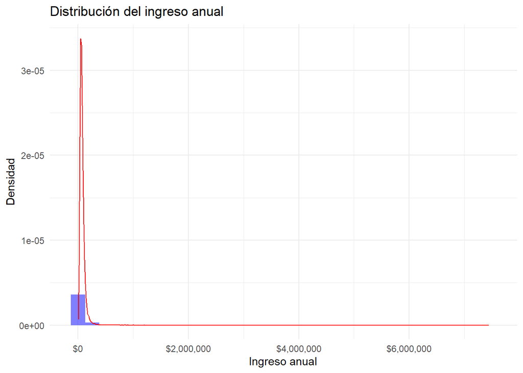

```r
library(ggplot2)
library(scales)

ggplot(train, aes(x = annual_inc)) +
  geom_histogram(aes(y = ..density..), bins = 30, fill = "blue", alpha = 0.5) +
  geom_density(color = "red") +
  scale_x_continuous(labels = dollar) +
  labs(title = "Distribución del ingreso anual",
       x = "Ingreso anual",
       y = "Densidad") +
  theme_minimal()
```

La siguiente Figura muestra el histograma con 50 bins del intervalo de ingreso de 0 al percentil 95.

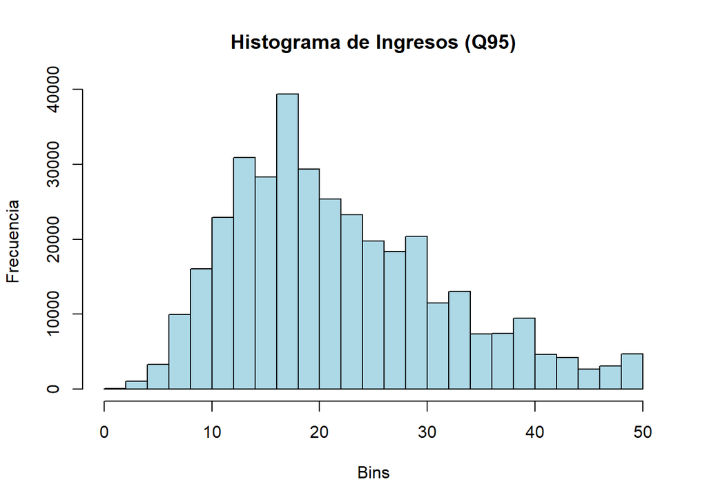

```r
q95<- round(quantile(train$annual_inc,0.95),0)
income_q95 <- train$annual_inc[which(train$annual_inc<=q95)]
#table(cut_income) # Muestra cuántos registros hay por intervalo

#prop.table(table(train$annual_inc))*100  # Indica la proporción (en base a 100) por intervalo del total de datos

# se guarga en un data frame la variable de respuesta y los bins
cut_income <- cut(income_q95,breaks=50)
income_q95_df <- data.frame(  annual_inc = factor(cut_income , labels =  names(table(cut_income))),
                                y =train$y[which(train$annual_inc<=q95)])

# Crear un histograma de los bins
hist(as.numeric(income_q95_df$annual_inc),
     col = "lightblue",
     main = "Histograma de Ingresos (Q95)",
     xlab = "Bins",
     ylab = "Frecuencia")
```

```r
n_q95 <- length(train$y[which(train$annual_inc>q95)])

income_df <- rbind(income_q95_df,
                  data.frame(
                              annual_inc  = rep("Ingreso_mayor", n_q95),
                              y = train$y[which(train$annual_inc>q95)])
)
```

##### Variable int_rate (Tasa de interés)

La siguiente Figura muestra el histograma con 20 bins.

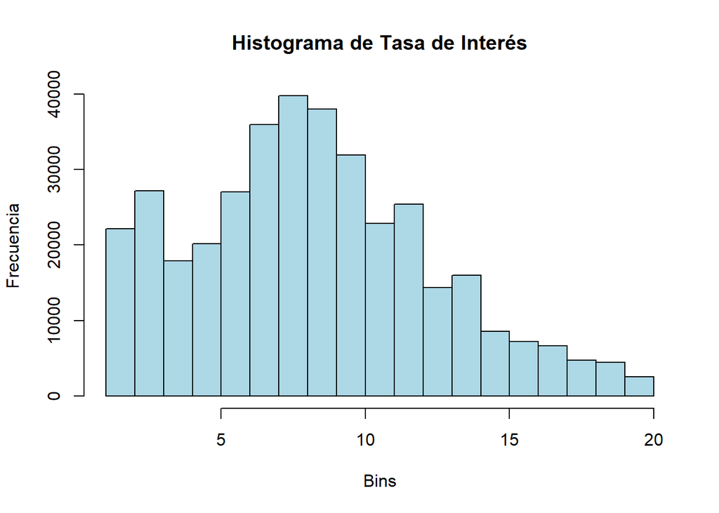

```r
# se guarga en un data frame la variable de respuesta y los bins
cut_rate <- cut(train$int_rate, breaks = 20)
int_rate_df <- data.frame( int_rate = factor(cut_rate , labels =  names(table(cut_rate))),
                            y = train$y)

# Crear un histograma de los bins
hist(as.numeric(int_rate_df$int_rate),
     col = "lightblue",
     main = "Histograma de Tasa de Interés",
     xlab = "Bins",
     ylab = "Frecuencia")
```

##### Variables “mths_since_last_delinq” y “mths_since_last_record”

Las variables “mths_since_last_delinq” y “mths_since_last_record” corresponden a los meses desde el último fraude/manejo inadecuado de la cuenta y el número de meses desde el último registro público (ej: bancarrota, sentencias, juicios, ejecuciones hipotecarias, etc.). Estas variables tienen muchos NA, pero no se debe a un error,sino a la naturaleza de la variable, puesto que si no aplica para una persona estas características, el registro de esta persona es vacío. Por lo tanto, los NA se agruparán de manera independiente.

```r
cat("Porcentaje de NA para mths_since_last_delinq: ",sum(is.na(train$mths_since_last_delinq))/nrow(train), "\n")
```

```
Porcentaje de NA para mths_since_last_delinq:  0.5369145
```

```r
cat("Porcentaje de NA para mths_since_last_record:",sum(is.na(train$mths_since_last_delinq))/nrow(train))
```

[output not shown]

Se procede a crear los bins sin los NA.

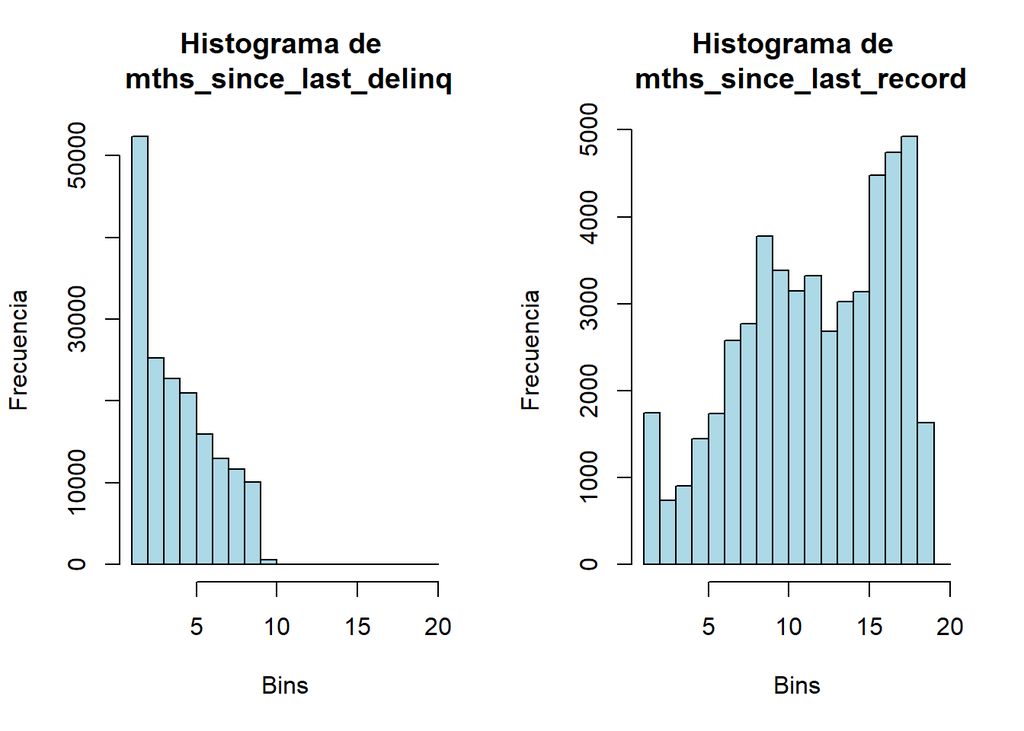

```r
delinq<- train$mths_since_last_delinq[which(is.na(train$mths_since_last_delinq)==FALSE)] #quitando los NA para obtener los no vacíos
record<-train$mths_since_last_record[which(is.na(train$mths_since_last_record)==FALSE)]  #Se quitan los NA para obtener los no vacíos

cut_delinq <-cut(delinq,breaks=20,labels=FALSE)
cut_record <- cut(record,breaks=20,labels=FALSE)

delinq_df <- data.frame(mths_since_last_delinq= factor(cut_delinq , labels =  names(table(cut_delinq))),
                        y = train$y[which(is.na(train$mths_since_last_delinq)==FALSE)])

record_df <- data.frame(mths_since_last_record = factor(cut_record, labels =  names(table(cut_record))),
                        y = train$y[which(is.na(train$mths_since_last_record)==FALSE)])

par(mfrow=c(1,2))

# Crear un histograma de los bins
hist(as.numeric(delinq_df$mths_since_last_delinq),
     col = "lightblue",
     main = "Histograma de \n mths_since_last_delinq",
     xlab = "Bins",
     ylab = "Frecuencia")

hist(as.numeric(record_df$mths_since_last_record),
     col = "lightblue",
     main = "Histograma de \n mths_since_last_record",
     xlab = "Bins",
     ylab = "Frecuencia")
```

```r
n_na_delinq <- length(train$mths_since_last_delinq[which(is.na(train$mths_since_last_delinq))])
n_na_record <- length(train$mths_since_last_record[which(is.na(train$mths_since_last_record))])

delinq_df_c<- rbind(delinq_df,
                   data.frame(
                              mths_since_last_delinq  = rep("NA", n_na_delinq),
                        y = train$y[which(is.na(train$mths_since_last_delinq))]))

record_df_c<- rbind(record_df,
                   data.frame(
                             mths_since_last_record  = rep("NA", n_na_record),
                        y = train$y[which(is.na(train$mths_since_last_record))]))
```

##### Cálculo del WOE

```
Variable: annual_inc
                              Categoria         WOE Total_buenos Total_malos
(1.75e+03,4.86e+03] (1.75e+03,4.86e+03] -0.86408531            4          15
(4.86e+03,7.82e+03] (4.86e+03,7.82e+03] -0.49141003            7          37
(7.82e+03,1.08e+04] (7.82e+03,1.08e+04] -0.54226844           60         287
(1.08e+04,1.37e+04] (1.08e+04,1.37e+04] -0.59035615          129         586
(1.37e+04,1.67e+04] (1.37e+04,1.67e+04] -0.43402792          223        1183
(1.67e+04,1.97e+04] (1.67e+04,1.97e+04] -0.34311252          281        1632
(1.97e+04,2.26e+04] (1.97e+04,2.26e+04] -0.39835219          545        2993
(2.26e+04,2.56e+04] (2.26e+04,2.56e+04] -0.30188402          910        5502
(2.56e+04,2.86e+04] (2.56e+04,2.86e+04] -0.38139714          868        4847
(2.86e+04,3.15e+04] (2.86e+04,3.15e+04] -0.28634662         1445        8872
(3.15e+04,3.45e+04] (3.15e+04,3.45e+04] -0.29192500         1227        7492
(3.45e+04,3.74e+04] (3.45e+04,3.74e+04] -0.28688876         1993       12229
(3.74e+04,4.04e+04] (3.74e+04,4.04e+04] -0.23356791         2446       15830
(4.04e+04,4.34e+04] (4.04e+04,4.34e+04] -0.20906001         1659       11004
(4.34e+04,4.63e+04] (4.34e+04,4.63e+04] -0.13709684         2047       14590
(4.63e+04,4.93e+04] (4.63e+04,4.93e+04] -0.12139458         1415       10246
(4.93e+04,5.23e+04] (4.93e+04,5.23e+04] -0.08718559         2661       19936
(5.23e+04,5.52e+04] (5.23e+04,5.52e+04] -0.09351528         1984       14771
(5.52e+04,5.82e+04] (5.52e+04,5.82e+04] -0.04953485         1178        9166
(5.82e+04,6.11e+04] (5.82e+04,6.11e+04] -0.11843160         2301       16709
(6.11e+04,6.41e+04] (6.11e+04,6.41e+04]  0.06603958          970        8473
(6.41e+04,6.71e+04] (6.41e+04,6.71e+04] -0.01776263         1763       14159
(6.71e+04,7e+04]       (6.71e+04,7e+04]  0.05522163         1675       14471
(7e+04,7.3e+04]         (7e+04,7.3e+04]  0.11468668          697        6393
(7.3e+04,7.59e+04]   (7.3e+04,7.59e+04]  0.11862551         1328       12225
(7.59e+04,7.89e+04] (7.59e+04,7.89e+04]  0.10942652          617        5630
(7.89e+04,8.19e+04] (7.89e+04,8.19e+04]  0.14737476         1176       11142
(8.19e+04,8.48e+04] (8.19e+04,8.48e+04]  0.22428798          541        5538
(8.48e+04,8.78e+04] (8.48e+04,8.78e+04]  0.21401475          894        9055
(8.78e+04,9.08e+04] (8.78e+04,9.08e+04]  0.25444184          904        9534
(9.08e+04,9.37e+04] (9.08e+04,9.37e+04]  0.23355267          397        4103
(9.37e+04,9.67e+04] (9.37e+04,9.67e+04]  0.24267034          611        6370
(9.67e+04,9.96e+04] (9.67e+04,9.96e+04]  0.26447022          320        3412
(9.96e+04,1.03e+05] (9.96e+04,1.03e+05]  0.22688707          826        8475
(1.03e+05,1.06e+05] (1.03e+05,1.06e+05]  0.35465985          372        4340
(1.06e+05,1.09e+05] (1.06e+05,1.09e+05]  0.28394582          223        2426
(1.09e+05,1.11e+05] (1.09e+05,1.11e+05]  0.32055269          462        5208
(1.11e+05,1.14e+05] (1.11e+05,1.14e+05]  0.46777227          125        1637
```

[output cut: 50 more lines]

```
(1.09e+05,1.11e+05]  5670     1.520009e-02
(1.11e+05,1.14e+05]  1762     4.723557e-03
(1.14e+05,1.17e+05]  3217     8.624110e-03
(1.17e+05,1.2e+05]   6264     1.679249e-02
(1.2e+05,1.23e+05]   1028     2.755855e-03
(1.23e+05,1.26e+05]  3611     9.680342e-03
(1.26e+05,1.29e+05]   960     2.573561e-03
(1.29e+05,1.32e+05]  3230     8.658960e-03
(1.32e+05,1.35e+05]  1895     5.080102e-03
(1.35e+05,1.38e+05]   770     2.064210e-03
(1.38e+05,1.41e+05]  2385     6.393690e-03
(1.41e+05,1.44e+05]   685     1.836343e-03
(1.44e+05,1.47e+05]  1229     3.294694e-03
(1.47e+05,1.5e+05]   3485     9.342562e-03
Ingreso_mayor       16463     4.413389e-02
```

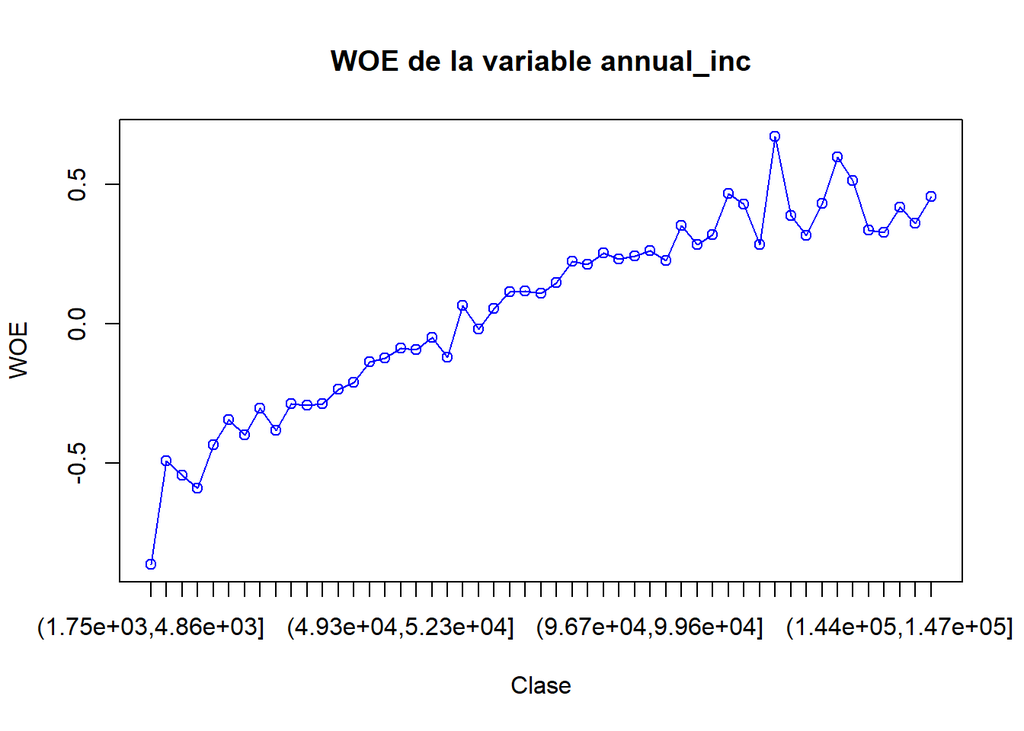

```
Variable: int_rate
              Categoria         WOE Total_buenos Total_malos Total
(5.4,6.45]   (5.4,6.45]  1.74256380          196        9173  9369
(6.45,7.48] (6.45,7.48]  1.44542813          357       12399 12756
(7.48,8.52] (7.48,8.52]  1.02573199         1141       26021 27162
(8.52,9.55] (8.52,9.55]  0.90061333          848       17067 17915
(9.55,10.6] (9.55,10.6]  0.56931756         1305       18854 20159
(10.6,11.6] (10.6,11.6]  0.38568116         2078       24982 27060
(11.6,12.6] (11.6,12.6]  0.33126027         2904       33061 35965
(12.6,13.7] (12.6,13.7]  0.13380794         3842       35901 39743
(13.7,14.7] (13.7,14.7] -0.02091829         4224       33812 38036
(14.7,15.7] (14.7,15.7] -0.08540306         3751       28151 31902
(15.7,16.8] (15.7,16.8] -0.34712198         3378       19514 22892
(16.8,17.8] (16.8,17.8] -0.39787713         3916       21502 25418
(17.8,18.8] (17.8,18.8] -0.53838749         2488       11871 14359
(18.8,19.9] (18.8,19.9] -0.59403812         2903       13101 16004
(19.9,20.9] (19.9,20.9] -0.59033096         1556        7049  8605
(20.9,21.9] (20.9,21.9] -0.77158527         1508        5699  7207
(21.9,23]     (21.9,23] -0.85546401         1486        5164  6650
(23,24]         (23,24] -0.90162251         1108        3677  4785
(24,25]         (24,25] -0.87190499         1010        3453  4463
(25,26.1]     (25,26.1] -1.04881521          666        1908  2574
            Total_porcentaje
(5.4,6.45]        0.02511635
(6.45,7.48]       0.03419619
(7.48,8.52]       0.07281569
(8.52,9.55]       0.04802640
(9.55,10.6]       0.05404210
(10.6,11.6]       0.07254225
(11.6,12.6]       0.09641471
(12.6,13.7]       0.10654274
(13.7,14.7]       0.10196663
(14.7,15.7]       0.08552265
(15.7,16.8]       0.06136871
(16.8,17.8]       0.06814039
(17.8,18.8]       0.03849350
(18.8,19.9]       0.04290341
(19.9,20.9]       0.02306822
(20.9,21.9]       0.01932047
(21.9,23]         0.01782727
(23,24]           0.01282759
(24,25]           0.01196438
(25,26.1]         0.00690036
```

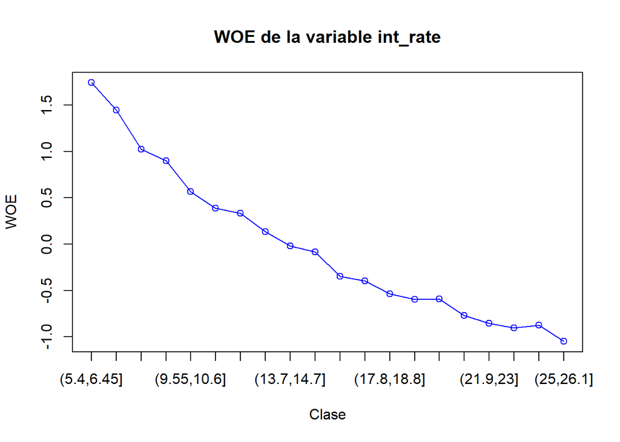

```
Variable: mths_since_last_delinq
   Categoria          WOE Total_buenos Total_malos  Total Total_porcentaje
1          1 -0.060893489         2684       20644  23328     6.253753e-02
2          2  0.014698608         3119       25873  28992     7.772154e-02
3          3  0.047640145         2639       22625  25264     6.772755e-02
4          4  0.077395316         2316       20456  22772     6.104701e-02
5          5  0.005418824         2273       18682  20955     5.617601e-02
6          6  0.002022038         1737       14229  15966     4.280154e-02
7          7  0.064621201         1329       11591  12920     3.463584e-02
8          8 -0.019723178         1298       10405  11703     3.137332e-02
9          9  0.013740360         1088        9019  10107     2.709477e-02
10        10 -0.211522225           80         532    612     1.640645e-03
11        11 -0.359350304            8          48     56     1.501244e-04
12        12  0.221539782            2          25     27     7.238140e-05
13        13 -1.312390578            2           5      7     1.876555e-05
14        14  0.732365406            0           8      8     2.144634e-05
15        15 -0.154937789            1          10     11     2.948872e-05
16        16  0.297047334            0           5      5     1.340396e-05
17        17 -1.513061273            2           4      6     1.608476e-05
18        18 -1.002235650            0           1      1     2.680793e-06
19        19 -1.002235650            0           1      1     2.680793e-06
20        20 -1.002235650            0           1      1     2.680793e-06
NA        NA -0.012978514        22087      178195 200282     5.369145e-01
```

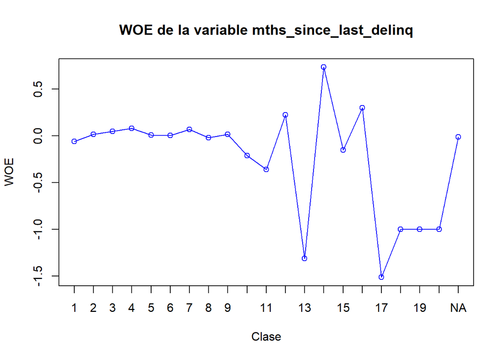

```
Variable: mths_since_last_record
   Categoria          WOE Total_buenos Total_malos  Total Total_porcentaje
1          1 -0.835840451          272         965   1237     3.316141e-03
2          2  0.215921790           45         461    506     1.356481e-03
3          3  0.128489490           71         664    735     1.970383e-03
4          4  0.181778827           83         818    901     2.415394e-03
5          5  0.193781060          132        1314   1446     3.876426e-03
6          6  0.453626893          125        1614   1739     4.661898e-03
7          7  0.427920700          190        2388   2578     6.911083e-03
8          8  0.391712561          211        2557   2768     7.420434e-03
9          9  0.327427939          306        3475   3781     1.013608e-02
10        10  0.194766226          309        3073   3382     9.066441e-03
11        11  0.345915262          250        2893   3143     8.425731e-03
12        12  0.132688738          321        3000   3321     8.902912e-03
13        13  0.078687984          272        2409   2681     7.187205e-03
14        14 -0.276067984          419        2601   3020     8.095994e-03
15        15 -0.299201251          444        2693   3137     8.409647e-03
16        16 -0.132571818          549        3933   4482     1.201531e-02
17        17 -0.062137857          546        4197   4743     1.271500e-02
18        18 -0.104294057          588        4333   4921     1.319218e-02
19        19  0.121825055          159        1472   1631     4.372373e-03
20        20 -3.199460227            1           0      1     2.680793e-06
NA        NA -0.005561499        35372      287499 322871     8.655502e-01
```

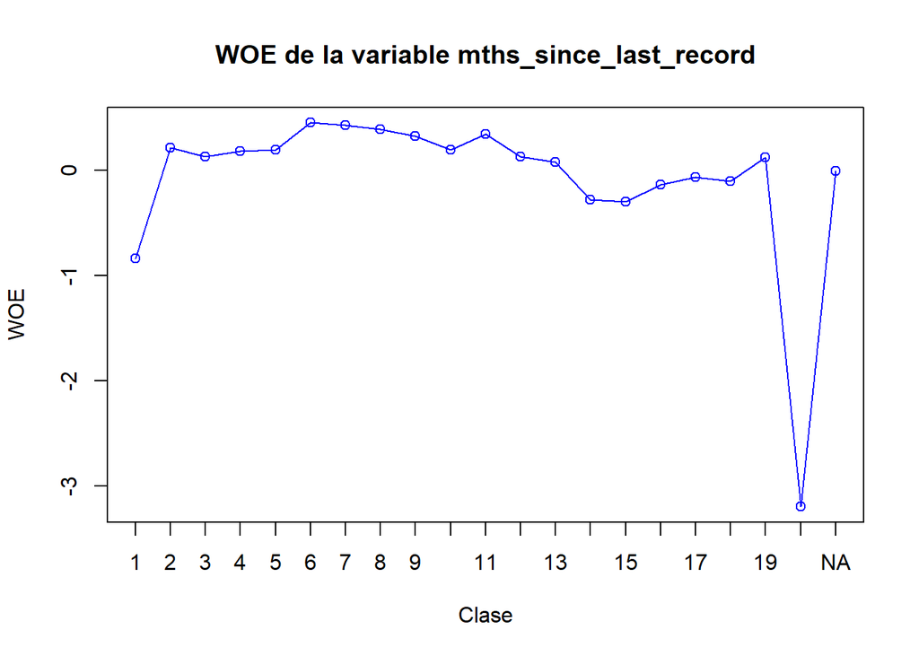

```r
train_numeric_var <- list(
  annual_inc = income_df,
  int_rate = int_rate_df,
  mths_since_last_delinq = delinq_df_c,
  mths_since_last_record = record_df_c
)

names(train_numeric_var) <- numeric_var

woe_results_numeric_var <- list()
i = 1
for(var_ in numeric_var ){
  woe_results_numeric_var[[var_]]<- calculate_woe(train_numeric_var[[var_,drop=FALSE]] , "y", numeric_var[i])
  i = i + 1
}

# Imprimir los resultados
for (i in 1:length(numeric_var)) {
  cat("Variable:", names(woe_results_numeric_var)[i], "\n")
  print(woe_results_numeric_var[[i]][[1]])
  plot_woe(woe_results_numeric_var[[i]][[1]], var_name = names(woe_results_numeric_var)[i])
  cat("\n")
}
```